# Motivation

## Calculate apparent temperature

We can calculate the apparent temperature now:

```python
def apparent_temperature(temp, p):
    """
    Calculate the apparent temperature [°C].

    Arguments
    ---------
    temp:
        Outdoor air temperature [°C].
    p:
        Outdoor partial vapour pressure [Pa].

    Example
    -------
    >>> round(apparent_temperature(temp=35, p=5061), 2)
    42.03

    """
    return -1.3 + 0.92 * temp + 2.2 * p / 1000

assert np.isclose(apparent_temperature(temp=35, p=5061), 42.03, atol=0.005)
```

That seems correct.

Rather than working with temperature and partial vapour pressure, we could work directly with temperature and relative humidity. We could redefine the function `apparent_temperature(temp, p)` to `apparent_temperature(temp, relhum)` or simply write a new function like `apparent_temperature_relum(temp, relhum)` if we are interested in keeping both versions for some reason.

```python
def apparent_temperature_relhum(temp, relhum):
    """
    Calculate the apparent temperature [°C].

    Arguments
    ---------
    temp:
        Outdoor air temperature [°C].
    relhum:
        Outdoor relative humidity [%].

    Example
    -------
    >>> round(apparent_temperature_rh(temp=35, relhum=90), 2)
    42.03

    """
    p = part_vap_pressure(temp=temp, relhum=relhum)
    return apparent_temperature(temp=temp, p=p)

assert np.isclose(apparent_temperature_relhum(temp=35, relhum=90), 42.03, atol=0.005)
```

We could actually plot a chart to see how apparent temperature changes at different temperatures and relative humidity levels:

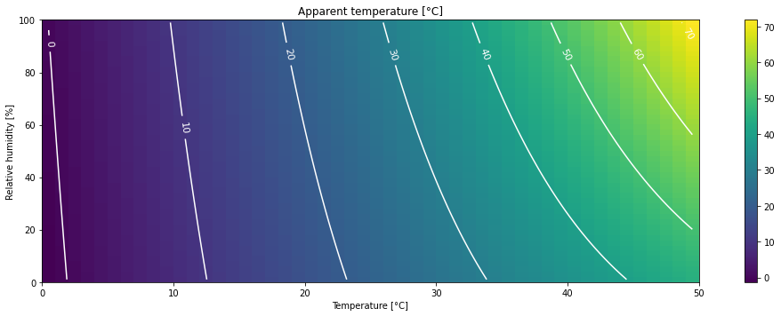

```python
temps = np.linspace(0, 50)   # Get a bunch of temperatures between 0 and 50.
rhs   = np.linspace(0, 100)  # Get a bunch of relative humidities between 0 and 100.

# Data to plot
xx, yy = np.meshgrid(temps, rhs)      # Create a grid using the previous two vectors
zz = apparent_temperature_relhum(xx, yy)  # Calculate the apparent temperature at each grid point

# Plot
fig, ax = plt.subplots(figsize=(15, 5))

# Define the plot extent (left, right, bottom, top)
extent = (temps.min(), temps.max(), rhs.min(), rhs.max())

# Plot array `zz` with the apparent temperature as an image
im = ax.imshow(zz, origin='lower', extent=extent, aspect=.2)
# with a colobar
cb = fig.colorbar(im)

# Add contour lines
cs = ax.contour(zz, origin='lower', colors='white', extent=extent)
# with labels
ax.clabel(cs, inline=True, fmt='%1d', fontsize=11)

plt.xlabel('Temperature [°C]')
plt.ylabel('Relative humidity [%]')
plt.title('Apparent temperature [°C]')

plt.tight_layout()
plt.show()
```

This shows graphically the variation of apparent temperature as air temperature and relative humidity changes.

The library behind this plot (and actually the previous plots as well) is [matplotlib](https://matplotlib.org/stable/users/index.html), a wonderful library to produce high-quality figures. To newcomers, matplotlib can be a bit overwhelming:

- there are seemingly different ways to achieve the same thing,
- it offers a vast amount of functionality and options,
- the learning curve varies depending on what you need to do.

In practice, it is common to search on the internet the particular thing you are looking for.

- [Basic tutorials](https://matplotlib.org/stable/users/getting_started/index.html) are helpful.
- [Matplotlib documentation is great](https://matplotlib.org/stable/users/index.html).
- There are cheatsheets created by the community that are quite handy.
- Books like [this one](https://github.com/rougier/scientific-visualization-book).

This is just the tip of the iceberg. There are [many other options](https://www.youtube.com/watch?v=FytuB8nFHPQ) to visualise data in Python!

# Heat stress index at the location

Now that we are familiar with apparent temperature and that the implementation in Python seems correct, we can continue.

The next step is to calculate the apparent temperature for the location given the weather data we loaded.

```python
df['temp_apparent'] = apparent_temperature_relhum(df['temp'], relhum=df['relhum'])
df
```

|  | temp | relhum | temp_apparent |
| --- | --- | --- | --- |
| 2001-01-01 00:00:00 | 16.0 | 78 | 16.537720 |
| 2001-01-01 01:00:00 | 15.6 | 82 | 16.246669 |
| 2001-01-01 02:00:00 | 15.1 | 85 | 15.798770 |
| 2001-01-01 03:00:00 | 14.8 | 87 | 15.535314 |
| 2001-01-01 04:00:00 | 14.4 | 88 | 15.121138 |
| ... | ... | ... | ... |
| 2001-12-31 19:00:00 | 17.9 | 67 | 18.189387 |
| 2001-12-31 20:00:00 | 17.5 | 69 | 17.834009 |
| 2001-12-31 21:00:00 | 17.2 | 71 | 17.587236 |
| 2001-12-31 22:00:00 | 16.8 | 73 | 17.226579 |
| 2001-12-31 23:00:00 | 16.5 | 75 | 16.975046 |

8760 rows × 3 columns

## Explore and analyse results

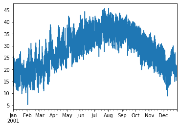

```python
df['temp_apparent'].plot()
```

We could compare how different the apparent temperature is from the air temperature.

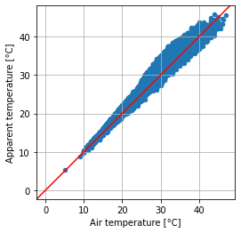

```python
fig, ax = plt.subplots()

# Plot air temperature vs apparent temperature
df.plot(ax=ax, x='temp', y='temp_apparent', kind='scatter')

# Add a reference line y=x
ax.axline((0, 0), slope=1, color='red')

# Make sure the X and Y axis are at the same scale
ax.set_aspect(1)

plt.xlabel('Air temperature [°C]')
plt.ylabel('Apparent temperature [°C]')
plt.grid()
plt.show()
```

We could also explore the amount of hours above/below certain temperatures.

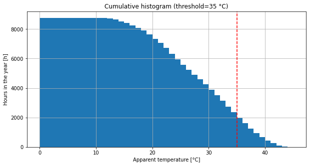

```python
threshold = 35  # This is just to plot a vertical line

fig, ax = plt.subplots(figsize=(10, 5))
ax.hist(df['temp_apparent'], bins=np.arange(0, 46, 1), cumulative=-1)
ax.axvline(x=threshold, color='red', ls='--')
plt.xlabel('Apparent temperature [°C]')
plt.ylabel('Hours in the year [h]')
plt.title(f'Cumulative histogram ({threshold=} °C)')
plt.grid()
plt.show()
```

We could also add columns to the tables with different thresholds and report `1` if it was surpassed at that hour, or `0` otherwise.

```python
thresholds = [30, 35, 40, 45]
cols = []
for threshold in thresholds:
    col = str(threshold)
    df[col] = np.where(df['temp_apparent'] >= threshold, 1, 0)
    cols.append(col)
df
```

|  | temp | relhum | temp_apparent | 30 | 35 | 40 | 45 |
| --- | --- | --- | --- | --- | --- | --- | --- |
| 2001-01-01 00:00:00 | 16.0 | 78 | 16.537720 | 0 | 0 | 0 | 0 |
| 2001-01-01 01:00:00 | 15.6 | 82 | 16.246669 | 0 | 0 | 0 | 0 |
| 2001-01-01 02:00:00 | 15.1 | 85 | 15.798770 | 0 | 0 | 0 | 0 |
| 2001-01-01 03:00:00 | 14.8 | 87 | 15.535314 | 0 | 0 | 0 | 0 |
| 2001-01-01 04:00:00 | 14.4 | 88 | 15.121138 | 0 | 0 | 0 | 0 |
| ... | ... | ... | ... | ... | ... | ... | ... |
| 2001-12-31 19:00:00 | 17.9 | 67 | 18.189387 | 0 | 0 | 0 | 0 |
| 2001-12-31 20:00:00 | 17.5 | 69 | 17.834009 | 0 | 0 | 0 | 0 |
| 2001-12-31 21:00:00 | 17.2 | 71 | 17.587236 | 0 | 0 | 0 | 0 |
| 2001-12-31 22:00:00 | 16.8 | 73 | 17.226579 | 0 | 0 | 0 | 0 |
| 2001-12-31 23:00:00 | 16.5 | 75 | 16.975046 | 0 | 0 | 0 | 0 |

8760 rows × 7 columns

And then summarise results by taken the total hours per month to get an idea of how conditions are.

```python
df_thresholds = df[cols].resample('M').sum()
df_thresholds
```

|  | 30 | 35 | 40 | 45 |
| --- | --- | --- | --- | --- |
| 2001-01-31 | 0 | 0 | 0 | 0 |
| 2001-02-28 | 10 | 0 | 0 | 0 |
| 2001-03-31 | 66 | 12 | 0 | 0 |
| 2001-04-30 | 162 | 38 | 0 | 0 |
| 2001-05-31 | 478 | 179 | 21 | 0 |
| 2001-06-30 | 601 | 317 | 59 | 0 |
| 2001-07-31 | 717 | 487 | 148 | 2 |
| 2001-08-31 | 715 | 504 | 171 | 1 |
| 2001-09-30 | 660 | 378 | 50 | 0 |
| 2001-10-31 | 379 | 89 | 0 | 0 |
| 2001-11-30 | 87 | 1 | 0 | 0 |
| 2001-12-31 | 0 | 0 | 0 | 0 |

The code above makes use of [pandas wonderful syntax to work with time series data](https://pandas.pydata.org/pandas-docs/stable/user_guide/timeseries.html#resampling).

- `df` contains hourly data.
- We want some of that data only (the thresholds).
- We want to go from hourly values to monthly values, an operation known as 'resampling'.
- There are several ways to resample data: taking the monthly maximum, minimum, average, sum...
  - In this case, we want the total amount of hours in a month, so it would be the sum.

Thus, we select the columns we want (`df[cols]`), resample by month (`.resample('M')`) using the sum (`.sum()`).

# Reporting

There is a template already prepared that contains how the report will look, and it is in `1-input/report-template.xlsx`. Take a moment to get familiar with the file, and see the inputs it requires from Python. Notice that the sheet `report` has a title, three figures and a table.

- The table hosts the numbers directly (the cells do not contain formulas).
- The figures read the data from the sheet `data`.
- The title of the report uses the location name provided in the sheet `data` as well.

The approach here will be to:

1. Read the name of the location from the EPW file.
2. Copy the report template to the output folder, and give it the name of the location to identify things easily.
3. Populate the output with the information available.

```python
# Python standar library
from shutil import copy  # Function to copy files

# Third party modules
import xlwings as xw  # One of the several libraries in Python to work with Excel files
```

## Location name

The name of the location is conveniently reported in the first line of the EPW file. It is a bit on an overkill to do it with pandas, but entirely possible.

```python
info = pd.read_csv(path, nrows=1, header=None)
info
```

|  | 0 | 1 | 2 | 3 | 4 | 5 | 6 | 7 | 8 | 9 |
| --- | --- | --- | --- | --- | --- | --- | --- | --- | --- | --- |
| 0 | LOCATION | ABU DHABI | - | ARE | IWEC Data | 412170 | 24.43 | 54.65 | 4.0 | 27.0 |

```python
# The name is in row 0, column 1, and we can convert the string to Title Case with `.title()`
location = info.at[0, 1].title()
location
```

```
'Abu Dhabi'
```

## Prepare output report file

```python
path_tpl = '1-input/report-template.xlsx'
path_out = f'2-output/report-{location}.xlsx'
copy(path_tpl, path_out)

print(f"File `{path_tpl}` copied to `{path_out}`")
```

```
File `1-input/report-template.xlsx` copied to `2-output/report-Abu Dhabi.xlsx`
```

## Populate the report

Looking at the Excel coordinates of where the information is expected, we can start populating the report.

The following makes heavy use of

- [`xlwings`](https://docs.xlwings.org/en/stable/) to write the data into Excel,
- [`pandas`](https://pandas.pydata.org/pandas-docs/stable/user_guide/timeseries.html#resampling) to work with time series as we did above.

The code below is explained line by line at high level. Some additional comments are provided below if you want to know more about how it works.

```python
# Load the workbook
wb = xw.Book(path_out)

# Write the value of a cell
wb.sheets['data'].range('C3').value = location

# Write a list of values, starting in a particular cell
# Technical detail: In the `xlwings` package, the default is to write lists/arrays per row
#                   To write lists/arrays as colums we need to use `tranpose=True`
# - Temperature
wb.sheets['data'].range('F4').options(transpose=True).value = df['temp'].resample('D').min().resample('M').mean().to_numpy()
wb.sheets['data'].range('G4').options(transpose=True).value = df['temp'].resample('D').max().resample('M').mean().to_numpy()
# - Relative humidity
wb.sheets['data'].range('F19').options(transpose=True).value = df['relhum'].resample('D').min().resample('M').mean().to_numpy()
wb.sheets['data'].range('G19').options(transpose=True).value = df['relhum'].resample('D').max().resample('M').mean().to_numpy()
# - Apparent temperature
wb.sheets['data'].range('F34').options(transpose=True).value = df['temp_apparent'].resample('M').min().to_numpy()
wb.sheets['data'].range('G34').options(transpose=True).value = df['temp_apparent'].resample('M').max().to_numpy()

# Write table
wb.sheets['report'].range('L24').value = df_thresholds.to_numpy()

# Save
wb.save(path_out)

# Close the workbook
wb.close()
```

## Notes on the code

In `xlwings`, like in other similar packages, starts by opening the workbook (the Excel file).

In Excel, cells within the same file (workbook) can be addressed with the sheet name and the coordinate (for example, the sheet `data` and cell `C3`) and cells can contain quite a bit of information (for example, cells hold values numbers, text, formulas, etc. but also styles like font type, text color, background colour, etc.). Thus, to point to the *value* of the cell `C3` in sheet `data` in the workbook `wb`: `wb.sheets['data'].range('C3').value`.

That works well for single values. If we have the list `[1, 2, 3]` to be written in cells A1, B1, C1 respectively, we have two options:

- Say that the first item in the list goes to A1, that the second goes to B1 and that the third one goes to C1, or
- Note that in `xlwings`, we can write several values at the same time, so `wb.sheets['mysheet'].range('A1').value = [1, 2, 3]` has the desired effect. In `xlwings` the default is to write 'per row'. If we wanted to write the list per column (this is, to cells A1, A2 and A3), we need to use `wb.sheets['mysheet'].range('A1').options(transpose=True).value = [1, 2, 3]`.

Turning now to the pandas bit, noe that there are two types of figures in the report:

- Air temperature and relative humidity report 'the monthly range of **average** daily min and max'.
  - For example, for air temperature in sheet `data`, column starting `F4`, we need to write the average daily minimums.
    - This is what `df['temp'].resample('D').min().resample('M').mean().to_numpy()` does.
    - `df['temp']` select the temperature, then
    - `.resample('D').min()` resamples hourly values (8760 values) to **daily values** (365 values) by taking the daily **minimum**, then
    - `.resample('M').mean()` resamples the daily values (365 values) to **monthly values** (12 values) by taking the monthly **mean**, then
    - `.to_numpy()` transforms the object to an array with just the values of the pandas object.
- Apparent temperature requires the 'monthly range of **absolute** min and max'.
  - This is similar to the previous, but we do not need the intermediate step of daily values. We can take directly the minimum and maximum over a month.

It is also possible to write whole tables directly, which is what `wb.sheets['report'].range('L24').value = df_thresholds.to_numpy()` does.

Finally, we need to save the changes to the file, and let Python know that it can close the file.

# Final remarks

This notebook showcases *a way* of going about this problem. This is really a 'first draft' of the notebook that intends to show the thinking process as it took place. Now that there is a solution in place that works, it would make sense to sort things out a bit better, and clean up things where needed. At the very least, the notebook should have annotations on why you did the things you did. Imagine that you open a notebook in a couple of years: will you be able to follow (1) the code and (2) its rationale?

A good habit with notebooks that do not take too long to run is to reset the kernel and run things all over again to make sure that there are no problems. The reason is that in notebooks one can go to previous cells, change something, then go directly to a cell a few rows below. Thus, the visual order top-to-bottom might not match the order in which the cells where actually executed. This then becomes a problem when you reopen the notebook or give it to somebody else.

Similarly to this example, you will need to think carefully about what you need to do in your exercise.

1. Devise a strategy.
2. See how you can accomplish that with Python.
3. Give it a go in your notebook, documenting things as you go along.